# Análise Espacial de Violência Física contra Crianças

### 7.2 Ajuste do modelo

Com o parâmetro de suavização selecionado ($h^* = 62$, vizinhança adaptativa, critério AIC), o modelo foi ajustado com a seguinte chamada:

```r
gwzinbr(data = dados_modelo_bn,
        formula = VF_2018_2022 ~ comodo + composta + mais5 + mulher_resp,
        lat = "lat_utm", long = "long_utm",
        offset = "log_casos_esp_vf", method = "adaptive_bsq",
        model = "negbin", force = TRUE, distancekm = FALSE, h = 62)
```

Estatísticas de ajuste do modelo RBNGP (vizinhança adaptativa, $h^* = 62$)

| Medida | Valor |
| --- | --- |
| *deviance* | 94,833 |
| AIC | 745,260 |
| AICc | 756,757 |
| Pseudo $R^2$ | 0,927 |
| Pseudo $R^2$ ajustado | 0,895 |

### 7.3 Estimativas locais dos coeficientes

As figuras a seguir apresentam os mapas das estimativas locais, considerando apenas os coeficientes localmente significativos ao nível de 10%.

#### 7.3.1 comodo

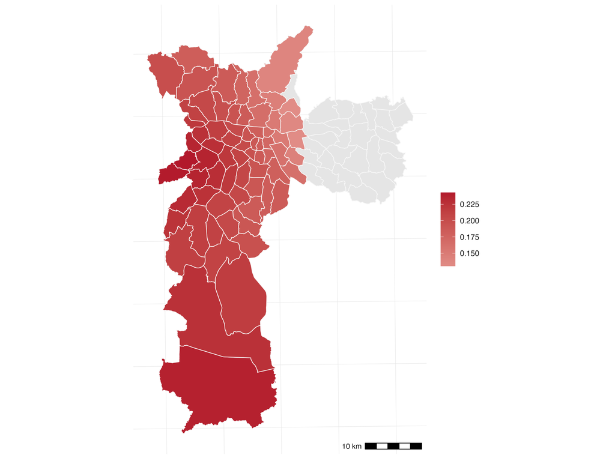

Mapa das estimativas locais dos coeficientes de comodo.

Medidas-resumo das estimativas locais dos coeficientes de cômodos (69 de 96 distritos significativos)

| Medida | Valor |
| --- | --- |
| Média | 0,195 |
| Desvio-padrão | 0,028 |
| Mínimo | 0,130 |
| 1º Quartil | 0,181 |
| Mediana | 0,196 |
| 3º Quartil | 0,214 |
| Máximo | 0,243 |

#### 7.3.2 composta

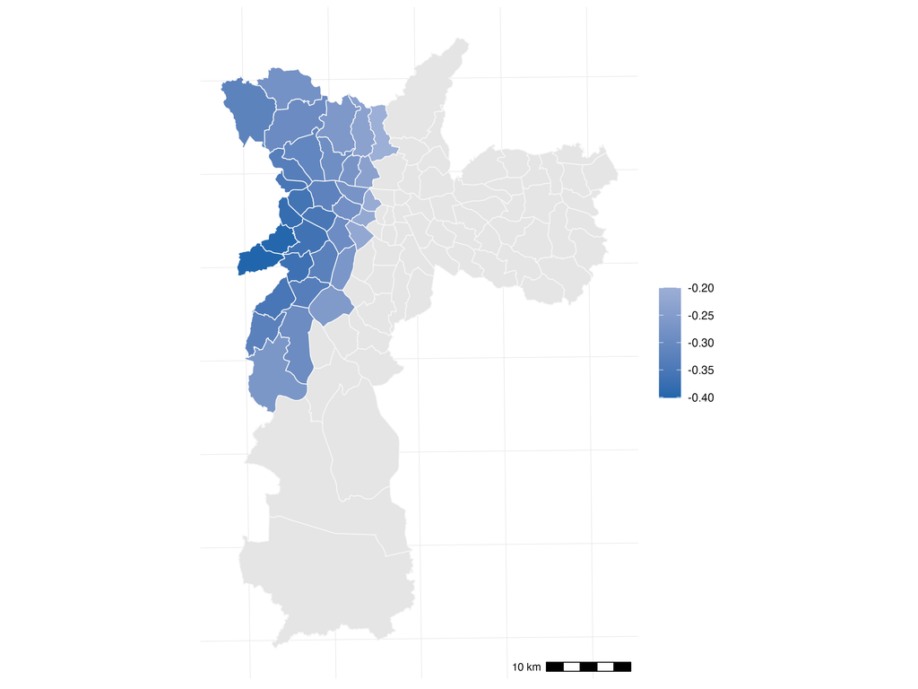

Mapa das estimativas locais dos coeficientes de composta.

Medidas-resumo das estimativas locais dos coeficientes de famílias compostas (34 de 96 distritos significativos)

| Medida | Valor |
| --- | --- |
| Média | -0,301 |
| Desvio-padrão | 0,055 |
| Mínimo | -0,401 |
| 1º Quartil | -0,348 |
| Mediana | -0,294 |
| 3º Quartil | -0,265 |
| Máximo | -0,200 |

#### 7.3.3 mais5

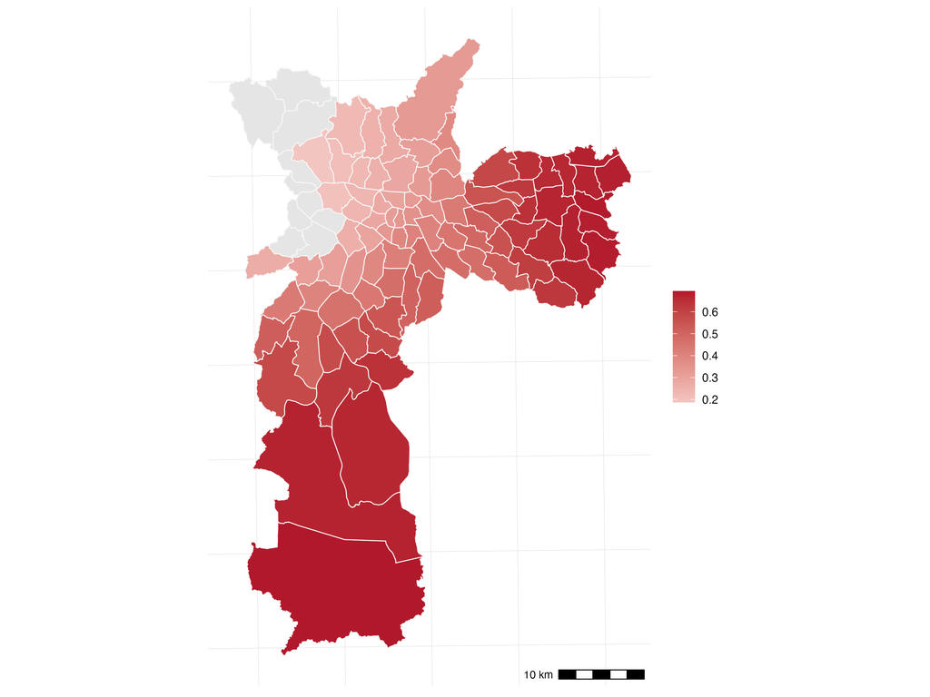

Mapa das estimativas locais dos coeficientes de mais5.

Medidas-resumo das estimativas locais dos coeficientes de domicílios com cinco ou mais moradores (86 de 96 distritos significativos)

| Medida | Valor |
| --- | --- |
| Média | 0,463 |
| Desvio-padrão | 0,155 |
| Mínimo | 0,187 |
| 1º Quartil | 0,326 |
| Mediana | 0,464 |
| 3º Quartil | 0,620 |
| Máximo | 0,694 |

#### 7.3.4 mulher_resp

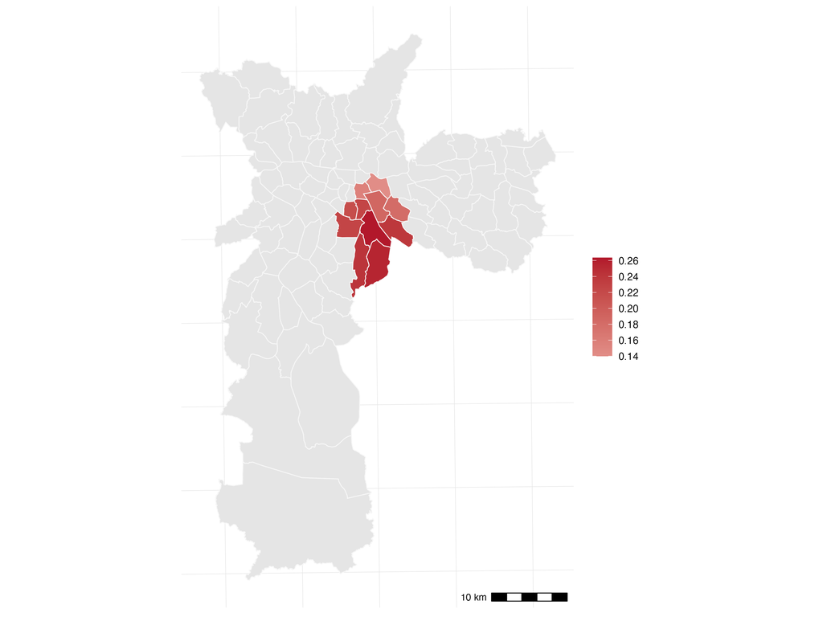

Mapa das estimativas locais dos coeficientes de mulher_resp.

Medidas-resumo das estimativas locais dos coeficientes de mulheres responsáveis (11 de 96 distritos significativos)

| Medida | Valor |
| --- | --- |
| Média | 0,212 |
| Desvio-padrão | 0,041 |
| Mínimo | 0,140 |
| 1º Quartil | 0,184 |
| Mediana | 0,225 |
| 3º Quartil | 0,240 |
| Máximo | 0,264 |

A estimação dos parâmetros pela RBNGP revelou forte variação espacial na associação entre as variáveis e os casos de violência infantil em São Paulo. O parâmetro referente ao número de cômodos mostra efeito positivo nas zonas periféricas (exceto na Zona Leste), enquanto o coeficiente de composta é mais negativo na região oeste e noroeste. O efeito positivo de mais5 destaca-se especialmente nas periferias da Zona Leste. Para mulher_resp, embora no modelo global o coeficiente não tenha apresentado significância, na análise local uma pequena região apresenta parâmetros estatisticamente significativos — evidenciando como a RGP consegue captar variações específicas por região que modelos globais não revelam.

### 7.4 Parâmetro de superdispersão ($\alpha$)

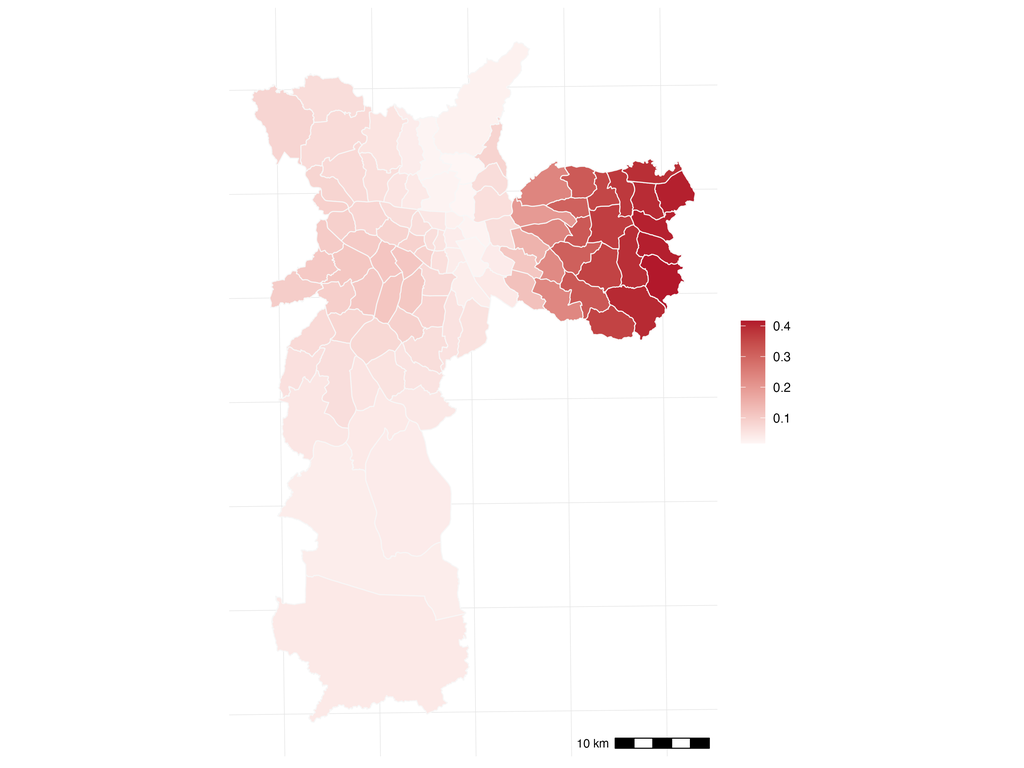

Mapa das estimativas locais do parâmetro de superdispersão ($\alpha$).

Medidas-resumo das estimativas locais do parâmetro de superdispersão ($\alpha$)

| Medida | Valor |
| --- | --- |
| Média | 0,131 |
| Desvio-padrão | 0,123 |
| Mínimo | 0,017 |
| 1º Quartil | 0,052 |
| Mediana | 0,079 |
| 3º Quartil | 0,127 |
| Máximo | 0,416 |

Os valores mais elevados de $\alpha$ concentram-se nos distritos da região leste de São Paulo, indicando maior variação não explicada pelas covariáveis do modelo nessas áreas. Isso sugere influência de fatores locais ou heterogeneidades não capturadas pelo modelo, tornando os casos de violência infantil mais dispersos em relação à média prevista. Nas demais regiões, predominam valores de $\alpha$ mais baixos, indicando ajuste mais homogêneo para esses dados.

### 7.5 Resíduos e diagnóstico espacial

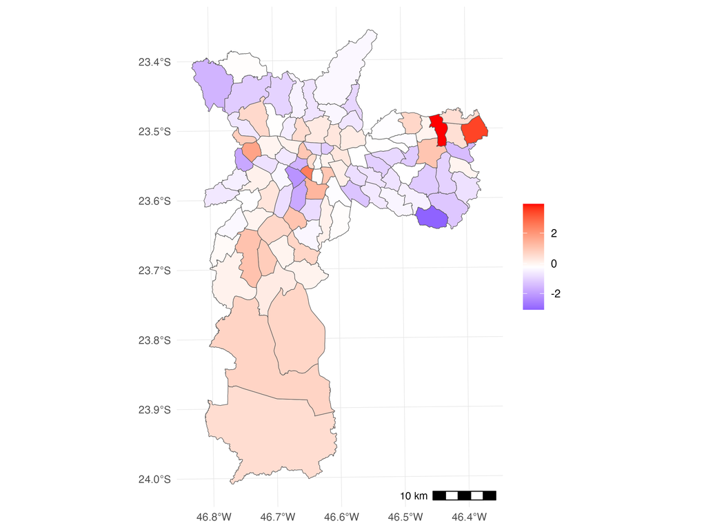

Resíduos padronizados — Modelo BN global.

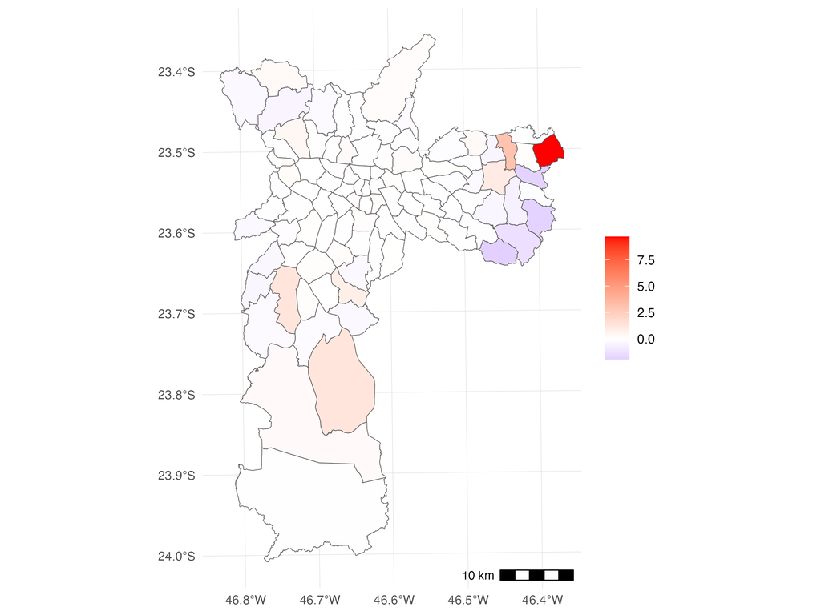

Resíduos padronizados — Modelo RBNGP (local).

A análise dos resíduos do modelo local destaca o distrito Itaim Paulista, na Zona Leste, com valor significativamente elevado. Esse padrão pode estar fortemente relacionado à presença da Casa de Isabel, referência regional para notificações de violência infantil. Por seu papel como centro de atendimento e suporte às vítimas, o distrito tende a concentrar registros, aumentando a discrepância entre o número de casos observados e o estimado pelo modelo.

O índice de Moran calculado para os resíduos padronizados do modelo RBNGP apresentou valor de $-0,0388$, com valor-p = 0,787, indicando ausência de autocorrelação espacial significativa — os resíduos estão distribuídos de forma espacialmente aleatória.

A comparação entre os dois painéis evidencia o ganho obtido com a modelagem local. No modelo global, observa-se concentração de resíduos elevados em distritos específicos, reflexo de padrões espaciais não capturados por coeficientes únicos. No modelo RBNGP, essa heterogeneidade é reduzida, com os resíduos distribuídos de forma mais homogênea — reforçando a relevância dos modelos geograficamente ponderados para captar a variação espacial dos efeitos das covariáveis.